# Functional Programming

with Fossil Pollen data

Ondřej Mottl

Science School of Quantitative Ecology 2024

# A function

## What is a `function` in R?

A function is a block of code which only runs when it is called.

```r
mean(x = c(1, 2, 3, 4, 5))
```

```
[1] 3
```

```r
function (x, trim = 0, na.rm = FALSE, ...)
{
    if (!is.numeric(x) && !is.complex(x) && !is.logical(x)) {
        warning("argument is not numeric or logical: returning NA")
        return(NA_real_)
    }
    if (isTRUE(na.rm))
        x <- x[!is.na(x)]
    if (!is.numeric(trim) || length(trim) != 1L)
        stop("'trim' must be numeric of length one")
    n <- length(x)
    if (trim > 0 && n) {
        if (is.complex(x))
            stop("trimmed means are not defined for complex data")
        if (anyNA(x))
            return(NA_real_)
        if (trim >= 0.5)
            return(stats::median(x, na.rm = FALSE))
        lo <- floor(n * trim) + 1
        hi <- n + 1 - lo
        x <- sort.int(x, partial = unique(c(lo, hi)))[lo:hi]
    }
    .Internal(mean(x))
}
```

## Parameters / Arguments

You can pass data, known as parameters/arguments, into a function.

```r
seq(
  from = 1,
  to = 10,
  by = 2
)
```

```
[1] 1 3 5 7 9
```

## Arguments matching

```r
# create some data
mydata <- rnorm(100)
```

```r
sd(mydata)
```

```
[1] 1.069997
```

```r
sd(x = mydata)
```

```
[1] 1.069997
```

```r
sd(x = mydata, na.rm = FALSE)
```

```
[1] 1.069997
```

```r
sd(na.rm = FALSE, x = mydata)
```

```
[1] 1.069997
```

```r
sd(na.rm = FALSE, mydata)
```

```
[1] 1.069997
```

## Creating a function - reason

```r
a <- rnorm(5)
b <- rnorm(5)
c <- rnorm(5)
d <- rnorm(5)
```

```r
(a - min(a)) / (max(a) - min(a))
(b - min(b)) / (max(b) - min(b))
(c - min(c)) / (max(c) - min(c))
(d - min(d)) / (max(d) - min(d))
```

```r
(█ - min(█)) / (max(█) - min(█))
```

## DRY - Don’t Repeat Yourself

If you have to repeat the **same code** more than twice, it is a good idea to create a function.

## Creating a function

```r
my_function <- function(<arguments>) {
  ## Do something interesting
}
```

```r
rescale_to_01 <- function(x) {
  (x - min(x)) / (max(x) - min(x))
}
```

```r
rescale_to_01(c(-10, 0, 10))
```

```
[1] 0.0 0.5 1.0
```

## Practical Exercise

1. What are your experiences with making functions?
2. How can we improve the function `rescale_to_01`?

```r
rescale_to_01 <- function(x) {
  (x - min(x)) / (max(x) - min(x))
}
```

```r
rescale_to_01 <- function(x) {
  x_range <-
    range(x, na.rm = TRUE, finite = TRUE)
  res <-
    (x - x_range[1]) / (x_range[2] - x_range[1])
  return(res)
}
```

`03:00`

# Functionals

## Functionals

[figure not shown]

[https://www.reddit.com/r/ProgrammerHumor/](https://www.reddit.com/r/ProgrammerHumor/comments/a5ggzi/functions/)

## Functionals

A functional is a function that

- takes a function as an **input**
- and returns a vector as **output**

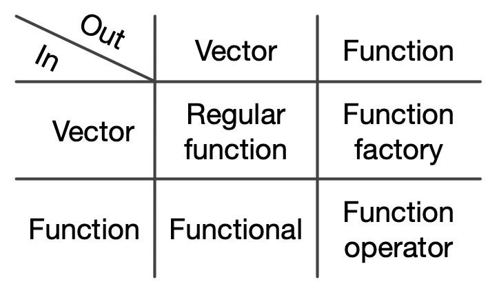

Bjarne Stroustrup:

To become significantly more reliable, code must become more transparent. In particular, nested conditions and loops must be viewed with great suspicion. Complicated control flows confuse programmers. Messy code often hides bugs.

[Advanced R](https://adv-r.hadley.nz/fp.html)

## {purrr} package

[figure not shown]

[purrr.tidyverse.org](https://purrr.tidyverse.org/)

## `purrr::map()`

[Advanced R](https://adv-r.hadley.nz/functionals.html)

## `purrr::map()` - name?

Why `map()`?

From Math:

an operation that associates each element of a given set with one or more elements of a second set

## `purrr::map()`

```r
add_1 <- function(x){
  return(x + 1)
}
```

```r
purrr::map(
  .x = 1:3,
  .f = add_1
  )
```

```
[[1]]
[1] 2

[[2]]
[1] 3

[[3]]
[1] 4
```

## `purrr::map()`

`purrr::map()` returns list. There are other variants `purrr::map` that return different types of objects.

- `purrr::map_dbl()` returns a numeric vector
- `purrr::map_chr()` returns a character vector
- `purrr::map_lgl()` returns a logical vector
- `purrr::map_int()` returns an integer vector

```r
purrr::map_dbl(
  .x = 1:3,
  .f = add_1
  )
```

```
[1] 2 3 4
```

## `purrr::map()`

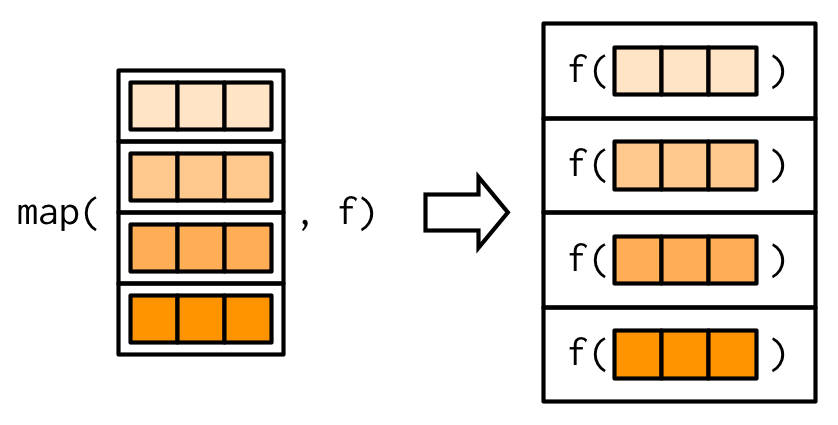

[Advanced R](https://adv-r.hadley.nz/functionals.html)

## `purrr::map()`

```r
my_list <-
  list(
    x = rnorm(5),
    y = rnorm(5),
    z = rnorm(5)
  )
```

```r
purrr::map_dbl(
  .x = my_list,
  .f = mean
  )
```

```
         x          y          z
-0.6117657 -0.1282808 -0.8007702
```

## `purrr::map()` - Anonymous functions

```r
get_length_of_unique <- function(x){
  unique(x)  %>%
    length()  %>%
    return()
}

purrr::map_dbl(
  .x = mtcars,
  .f = get_length_of_unique
  )
```

```
 mpg  cyl disp   hp drat   wt qsec   vs   am gear carb
  25    3   27   22   22   29   30    2    2    3    6
```

The magic of `~` (tilde operator):

```r
purrr::map_dbl(
  .x = mtcars,
  .f = ~ unique(.x) %>%
    length()
)
```

```
 mpg  cyl disp   hp drat   wt qsec   vs   am gear carb
  25    3   27   22   22   29   30    2    2    3    6
```

## `purrr::map()` - Anonymous functions

Tilde can be also used to combine custom and base functions.

```r
purrr::map_dbl(
  .x = list(
    x = rnorm(5),
    y = rnorm(5),
    z = rnorm(5)
  ),
  .f = ~ add_1(.x) %>%
    mean()
)
```

```
       x        y        z
1.098212 1.148211 1.068000
```

## Functional workflow

## Functional workflow - example

The data will be using Palmer’s `penguins` dataset.

[Palmer penguins dataset](https://allisonhorst.github.io/palmerpenguins/)

## Functional workflow - example

```r
library(palmerpenguins)
head(penguins)
```

```
# A tibble: 6 × 8
  species island    bill_length_mm bill_depth_mm flipper_length_mm body_mass_g
  <fct>   <fct>              <dbl>         <dbl>             <int>       <int>
1 Adelie  Torgersen           39.1          18.7               181        3750
2 Adelie  Torgersen           39.5          17.4               186        3800
3 Adelie  Torgersen           40.3          18                 195        3250
4 Adelie  Torgersen           NA            NA                  NA          NA
5 Adelie  Torgersen           36.7          19.3               193        3450
6 Adelie  Torgersen           39.3          20.6               190        3650
# ℹ 2 more variables: sex <fct>, year <int>
```

## Functional workflow - example

The goal is to plot the relationship between `bill_length_mm` and `bill_depth_mm` for each species.

[Palmer penguins dataset](https://allisonhorst.github.io/palmerpenguins/)

## Functional workflow - example

```r
data_penguins_by_species <-
  penguins %>%
  tidyr::nest(data_nested = -species)
```

```r
print(data_penguins_by_species)
```

```
# A tibble: 3 × 2
  species   data_nested
  <fct>     <list>
1 Adelie    <tibble [152 × 7]>
2 Gentoo    <tibble [124 × 7]>
3 Chinstrap <tibble [68 × 7]>
```

## Functional workflow - example

```r
data_penguins_by_species_lm <-
  data_penguins_by_species %>%
  dplyr::mutate(
    model = purrr::map(
      .x = data_nested,
      .f = ~ stats::lm(bill_length_mm ~ bill_depth_mm, data = .x)
    )
  )
```

## Functional workflow - example

```r
data_penguins_by_species_lm <-
  data_penguins_by_species %>%
  dplyr::mutate(
    model = purrr::map(
      .x = data_nested,
      .f = ~ stats::lm(bill_length_mm ~ bill_depth_mm, data = .x)
    ),
    model_coef = purrr::map(
      .x = model,
      .f = ~ stats::coef(.x)
    )
  )
```

## Functional workflow - example

```r
data_penguins_by_species_lm <-
  data_penguins_by_species %>%
  dplyr::mutate(
    model = purrr::map(
      .x = data_nested,
      .f = ~ stats::lm(bill_length_mm ~ bill_depth_mm, data = .x)
    ),
    model_coef = purrr::map(
      .x = model,
      .f = ~ stats::coef(.x)
    ),
    plot = purrr::map2(
      .x = data_nested,
      .y = model_coef,
      .f = ~ ggplot2::ggplot(
        data = .x,
        mapping = ggplot2::aes(x = bill_depth_mm, y = bill_length_mm)
      ) +
        ggplot2::geom_point() +
        ggplot2::geom_abline(
          intercept = .y[[1]],
          slope = .y[[2]],
          col = "red"
        ) +
        ggplot2::coord_cartesian(
           xlim = range(penguins$bill_depth_mm, na.rm = TRUE),
          ylim = range(penguins$bill_length_mm, na.rm = TRUE)
        )
    )
  )
```

## Functional workflow - example

```r
print(data_penguins_by_species_lm)
```

```
# A tibble: 3 × 5
  species   data_nested        model  model_coef plot
  <fct>     <list>             <list> <list>     <list>
1 Adelie    <tibble [152 × 7]> <lm>   <dbl [2]>  <gg>
2 Gentoo    <tibble [124 × 7]> <lm>   <dbl [2]>  <gg>
3 Chinstrap <tibble [68 × 7]>  <lm>   <dbl [2]>  <gg>
```

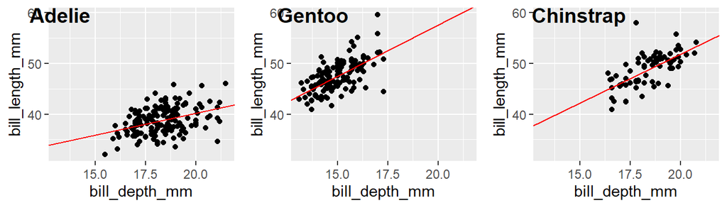

```r
ggpubr::ggarrange(
  plotlist = data_penguins_by_species_lm$plot,
  labels = data_penguins_by_species_lm$species,
  ncol = 3
)
```